# Homework_6

Ziad Al Bkhetan

November 12, 2015

# Data Loading

```r
wines_def <- read.table("http://archive.ics.uci.edu/ml/machine-learning-databases/wine-quality/winequality-red.csv", sep=";", header=TRUE)
head(wines_def)
```

```
##   fixed.acidity volatile.acidity citric.acid residual.sugar chlorides
## 1           7.4             0.70        0.00            1.9     0.076
## 2           7.8             0.88        0.00            2.6     0.098
## 3           7.8             0.76        0.04            2.3     0.092
## 4          11.2             0.28        0.56            1.9     0.075
## 5           7.4             0.70        0.00            1.9     0.076
## 6           7.4             0.66        0.00            1.8     0.075
##   free.sulfur.dioxide total.sulfur.dioxide density   pH sulphates alcohol
## 1                  11                   34  0.9978 3.51      0.56     9.4
## 2                  25                   67  0.9968 3.20      0.68     9.8
## 3                  15                   54  0.9970 3.26      0.65     9.8
## 4                  17                   60  0.9980 3.16      0.58     9.8
## 5                  11                   34  0.9978 3.51      0.56     9.4
## 6                  13                   40  0.9978 3.51      0.56     9.4
##   quality
## 1       5
## 2       5
## 3       5
## 4       6
## 5       5
## 6       5
```

# Data Preparation

For the target attribute we will create categorical variable with two different values good and bad, so we have binary classification problem.  
I have categorised the target variable “quality” to two different values:  
1: “good” if the original value of this attribute is bigger than 5  
2: “bad” if the original value of this attribute is less than or equal 5

and also I will divide the dataset into two different sets the first one for classifier training while the second is for the classifier testing.  
* partion percentage is 80:20  
* target attribute to maintain good distribution “quality”

```r
library(caret)
library(randomForest)
library(MASS)

wines <- wines_def
wines$quality <- factor(ifelse(wines_def$quality > 5, "good", "bad"))
summary(wines)
```

```
##  fixed.acidity   volatile.acidity  citric.acid    residual.sugar
##  Min.   : 4.60   Min.   :0.1200   Min.   :0.000   Min.   : 0.900
##  1st Qu.: 7.10   1st Qu.:0.3900   1st Qu.:0.090   1st Qu.: 1.900
##  Median : 7.90   Median :0.5200   Median :0.260   Median : 2.200
##  Mean   : 8.32   Mean   :0.5278   Mean   :0.271   Mean   : 2.539
##  3rd Qu.: 9.20   3rd Qu.:0.6400   3rd Qu.:0.420   3rd Qu.: 2.600
##  Max.   :15.90   Max.   :1.5800   Max.   :1.000   Max.   :15.500
##    chlorides       free.sulfur.dioxide total.sulfur.dioxide
##  Min.   :0.01200   Min.   : 1.00       Min.   :  6.00
##  1st Qu.:0.07000   1st Qu.: 7.00       1st Qu.: 22.00
##  Median :0.07900   Median :14.00       Median : 38.00
##  Mean   :0.08747   Mean   :15.87       Mean   : 46.47
##  3rd Qu.:0.09000   3rd Qu.:21.00       3rd Qu.: 62.00
##  Max.   :0.61100   Max.   :72.00       Max.   :289.00
##     density             pH          sulphates         alcohol
##  Min.   :0.9901   Min.   :2.740   Min.   :0.3300   Min.   : 8.40
##  1st Qu.:0.9956   1st Qu.:3.210   1st Qu.:0.5500   1st Qu.: 9.50
##  Median :0.9968   Median :3.310   Median :0.6200   Median :10.20
##  Mean   :0.9967   Mean   :3.311   Mean   :0.6581   Mean   :10.42
##  3rd Qu.:0.9978   3rd Qu.:3.400   3rd Qu.:0.7300   3rd Qu.:11.10
##  Max.   :1.0037   Max.   :4.010   Max.   :2.0000   Max.   :14.90
##  quality
##  bad :744
##  good:855
##
##
##
##
```

```r
indxTrain <- createDataPartition(y = wines$quality, p = 0.8)
winesDataSetTrain<- wines[indxTrain$Resample1,]
winesDataSetTest <- wines[-indxTrain$Resample1,]
```

# Important Variables Using Random Forests

In this step I will find the important variables to build classifier model using thiese variables.  
from the plots we can see that the first four most important variables are : alcohol + sulphates + total.sulfur.dioxide + volatile.acidity, so the final model be : quality ~ alcohol + sulphates + total.sulfur.dioxide + volatile.acidity

```r
rf<- randomForest(quality~., data = wines, importance=TRUE)
importance(rf)
```

```
##                           bad     good MeanDecreaseAccuracy
## fixed.acidity        22.65531 23.38343             32.77088
## volatile.acidity     39.23146 34.79532             47.93070
## citric.acid          18.96553 24.60422             31.16737
## residual.sugar       22.53986 22.83795             30.40553
## chlorides            26.92485 25.00332             34.94834
## free.sulfur.dioxide  22.27301 25.42036             33.13518
## total.sulfur.dioxide 34.53090 39.50886             50.76998
## density              25.58935 33.04764             41.68412
## pH                   26.82324 25.73700             36.78847
## sulphates            43.61922 49.02071             57.75706
## alcohol              56.41605 53.51551             69.89526
##                      MeanDecreaseGini
## fixed.acidity                53.80717
## volatile.acidity             88.81661
## citric.acid                  51.96605
## residual.sugar               43.89389
## chlorides                    57.72308
## free.sulfur.dioxide          47.31068
## total.sulfur.dioxide         80.55709
## density                      70.43838
## pH                           53.28846
## sulphates                    99.32228
## alcohol                     148.04168
```

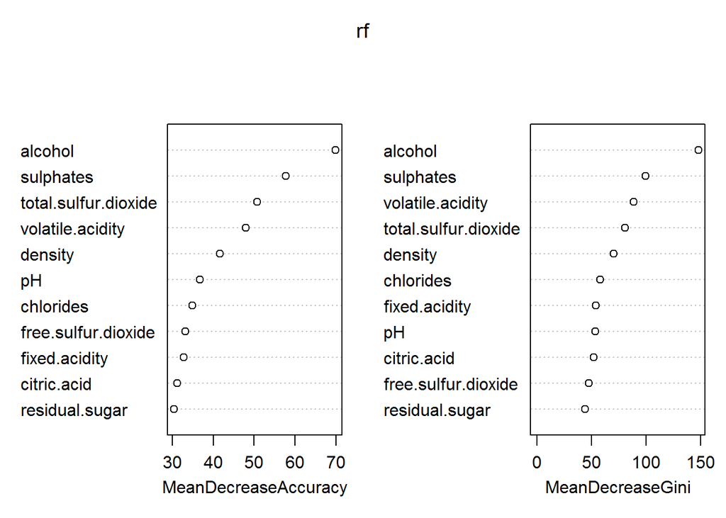

```r
varImpPlot(rf)
```

# Comparing LDA/QDA Using K-Folds Cross Validation

We will applay LDA and QDA using two different models to compare between them, the first model contains the first four important variables quality ~ alcohol + sulphates + total.sulfur.dioxide + volatile.acidity, while the second contains all variables  
in both cases we will train on the training dataset and test on the testing dataset then compare between these classifiers.

```r
#First Model
train_control <- trainControl(method="cv", number=10)
mat1 <- sapply(c('lda', 'qda'), function (met) {
  modelFit<- train(quality~alcohol + sulphates + total.sulfur.dioxide + volatile.acidity, method=met,preProcess=c('scale', 'center'), data=winesDataSetTrain, trControl=train_control)
  confusionMatrix(winesDataSetTest$quality, predict(modelFit, winesDataSetTest))$overall
})

# second Model
train_control <- trainControl(method="cv", number=10)
mat2 <- sapply(c('lda', 'qda'), function (met) {
  modelFit<- train(quality~., method=met,preProcess=c('scale', 'center'), data=winesDataSetTrain, trControl=train_control)
  confusionMatrix(winesDataSetTest$quality, predict(modelFit, winesDataSetTest))$overall
})
```

# Results

## Comparision using the First Model

these are the result using the classifier with this model: quality~alcohol + sulphates + total.sulfur.dioxide + volatile.acidity

```r
round(mat1*100,2)
```

```
##                  lda   qda
## Accuracy       76.18 75.24
## Kappa          52.36 50.32
## AccuracyLower  71.11 70.12
## AccuracyUpper  80.74 79.87
## AccuracyNull   50.16 52.04
## AccuracyPValue  0.00  0.00
## McnemarPValue  20.70 65.27
```

## Comparision Using The Second Model

Here are the results using the model with all attributes quality~.

```r
round(mat2*100,2)
```

```
##                  lda   qda
## Accuracy       76.80 74.29
## Kappa          53.53 47.99
## AccuracyLower  71.78 69.13
## AccuracyUpper  81.32 79.00
## AccuracyNull   51.10 57.99
## AccuracyPValue  0.00  0.00
## McnemarPValue  41.58 15.11
```

# Remarks

We can see the difference between these classifiers which change when we use different models.  
it is hard to detrmine which one is better because I got different resaults when I tried the test many times, but in general the diferences were slight and the cloassifiers are approximatly similar.